# Measles Analysis

**Measles Data**

The main data examined in this study focuses on measles and rubella cases across the world. There are two versions of this data: one that organizes data by month and one that organizes data by year. It was downloaded from the provisional monthly measles and rubella data of the World Health Organization on 2025-06-12. The World Health Organization collected this data from January 2012 to June 2025, and each observation recorded is a country at the specified month or year. The purpose of WHO collecting disease-specific data such as this is to track global outbreaks and aid policy decisions.

**Supplemental Data**

Supplemental data was also used in this study to analyze trends and possible correlations. One of these data sets was focused on hisotrical Covid-19 data from across the world; it contains the total number of Covid-19 cases in each country from January 2020 to March 2023. This data was accessed via a secondary website, called API Ninjas, that collects various sets of data. API Ninjas most likely obtained this data and any country or health-based data from public census data. The second supplemental data set was focused on the Gross Domestic Product (GDP) of each country by year; it was collected from 1980 to 2026, as well as projected up to 2029. This data was also accessed via API Ninjas.

**Research Questions**

**RQ1:** How does the concentration of measles compare across countries?

**RQ2:** Did measles reporting drop during the COVID‑19 pandemic (2020-2021), and does the later rebound suggest it was suppressed?

**RQ3:** Is there a significant difference in mean GDP growth between countries with high vs. low measles burden in 2019?

Research Question 1

**Lollipop Graph**

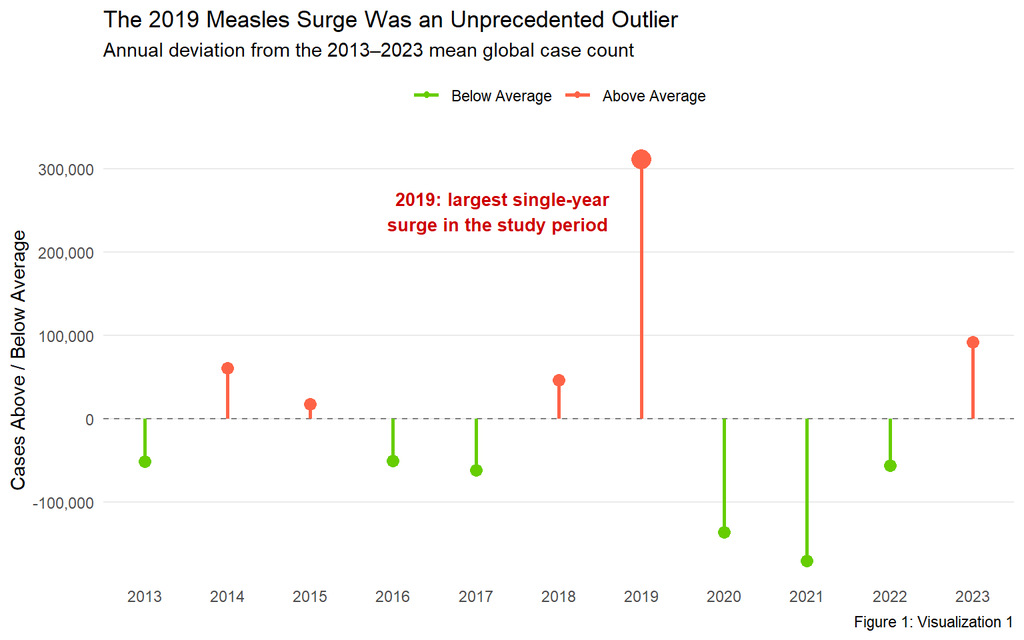

**Measles Concentration**

Figure 2: Table 1

Global Measles Concentration by Year

How burden is distributed across countries, 2013–2023

| Year | Global Cases | Top Country | Share of Global Cases Top Country | Share of Global Cases 2nd & 3rd Countries | # Major Burden Countries |  |
| --- | --- | --- | --- | --- | --- | --- |
| 2013 | 175,535 | Nigeria | 31.1% | 21.2% |  | 2 |
| 2014 | 285,516 | India | 27.8% | 36.6% | 3 |  |
| 2015 | 243,599 | India | 33.3% | 25.7% | 2 |  |
| 2016 | 176,155 | India | 38.8% | 30.2% | 3 |  |
| 2017 | 164,794 | India | 34.5% | 20.5% | 2 |  |
| 2018 | 271,650 | Ukraine | 19.3% | 20.2% | 2 |  |
| 2019 | <sup>1</sup> 532,303 | Madagascar | 39.4% | 19.5% | 2 |  |
| 2020 | 92,416 | Democratic Republic of the Congo | 15.5% | 19.9% | 2 |  |
| 2021 | 58,914 | Nigeria | 18.2% | 25.7% | 4 |  |
| 2022 | 171,922 | India | 25.0% | 25.6% | 3 |  |
| 2023 | 317,602 | India | 21.4% | 21.6% | 2 |  |

**Heatmap**

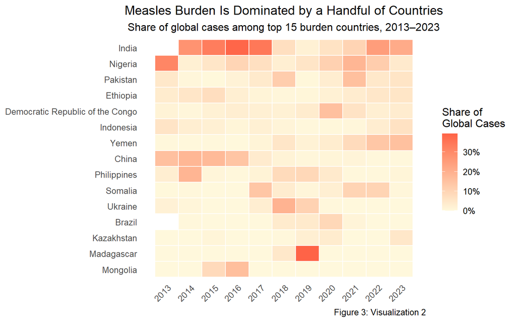

**Country Burden**

Figure 4: Table 2

Chronic Measles Burden by Country

Top 15 countries by total measles cases, 2013–2023

| Country | Total Cases | Peak Year | Peak Cases | Global Share |
| --- | --- | --- | --- | --- |
| India | 445,393 | 2015 | 82,461 | 17.6% |
| Madagascar | 225,773 | 2019 | <sup>1</sup> 213,291 | 8.9% |
| Nigeria | 192,673 | 2013 | 55,448 | 7.6% |
| China | 164,530 | 2014 | 52,485 | 6.5% |
| Philippines | 142,368 | 2014 | 53,906 | 5.6% |
| Ukraine | 121,509 | 2019 | 57,332 | 4.8% |
| Yemen | 108,880 | 2023 | 49,571 | 4.3% |
| Pakistan | 92,054 | 2018 | 33,007 | 3.6% |
| Ethiopia | 78,240 | 2015 | 17,778 | 3.1% |
| Democratic Republic of the Congo | 75,016 | 2019 | 18,467 | 3.0% |
| Somalia | 65,892 | 2017 | 23,353 | 2.6% |
| Indonesia | 59,422 | 2023 | 19,879 | 2.3% |
| Mongolia | 49,351 | 2016 | 28,703 | 1.9% |
| Brazil | 41,279 | 2019 | 20,901 | 1.6% |
| Kazakhstan | 35,130 | 2023 | 15,111 | 1.4% |

<sup>1</sup> Madagascar's total is almost entirely from its 2019 outbreak, unlike India whose burden is spread across multiple years.

Research Question 2

**Line Graph**

[figure not shown]

**Measles vs. COVID-19**

Figure 6: Table 3

Total Measles and COVID-19 Cases by Country

Countries with Highest Concentration of COVID-19 Cases in 2020 and 2022

| Country | 2020 Measles | 2020 COVID-19 | 2022 Measles | 2022 COVID-19 |
| --- | --- | --- | --- | --- |
| India | 5,598 | 10,286,709 | 43,578 | 44,679,873 |
| Brazil | 8,427 | 7,681,032 | 42 | 36,331,281 |
| France | 240 | 2,677,660 | 19 | 39,498,188 |
| Italy | 105 | 2,107,166 | 15 | 25,143,705 |
| Spain | 93 | 1,928,265 | 1 | 13,684,258 |
| Germany | 73 | 1,719,737 | 15 | 37,369,866 |
| Argentina | 65 | 1,625,514 | 2 | 9,891,139 |
| Mexico | 196 | 1,426,094 | 0 | 7,234,467 |

**COVID-19 Means**

Figure 7: Table 4

Average Number of COVID-19 Cases by Region

Comparison of Mean Cases by Region in 2020 and 2022

| Region | Mean Cases 2020 | Mean Cases 2022 |
| --- | --- | --- |
| AFR | 44,272 | 199,451 |
| AMR | 496,920 | 2,603,420 |
| EMR | 186,691 | 784,347 |
| EUR | 396,425 | 4,249,915 |
| SEAR | 1,318,740 | 6,678,122 |
| WPR | 50,850 | 2,985,378 |

**Lollipop Graph**

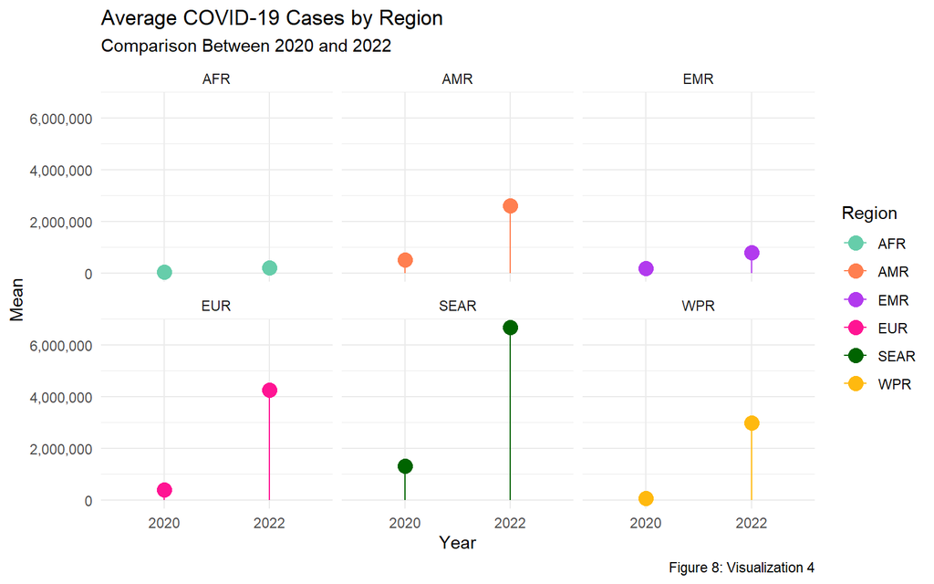

**Bar Graph**

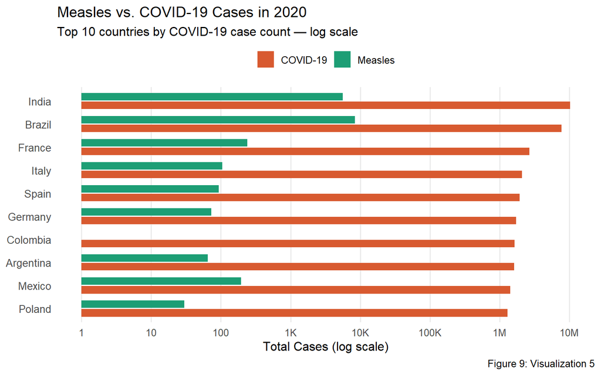

Research Question 3

**Hypotheses**

**Null Hypothesis:** There is no difference in mean GPD growth between high and low measles burden countries in 2019

**Alternative Hypothesis:** There is a difference in mean GDP growth between high and low measles burden countries in 2019

**T-Test**

**Two-Sample t-test Results**

Comparison of mean GDP growth between high and low measles burden countries in 2019

| Mean difference | Mean GDP growth (Low Measles) | Mean GDP growth (High Measles) | t statistic | p-value | df | CI lower | CI upper | Method | Alternative Hypothesis |
| --- | --- | --- | --- | --- | --- | --- | --- | --- | --- |
| −0.5287 | 2.5667 | 3.0954 | −1.0426 | 0.2992 | 120.9999 | −1.5328 | 0.4753 | Welch Two Sample t-test | Two-sided test (μ₁ ≠ μ₂) |

**Conclusion**

Using the 2019 data, a year marked by a notable rise in measles cases, countries were classified as high measles burden if their lab-confirmed measles cases exceeded the median of 48 cases. A two sample t-test resulted in no significant difference in mean GDP growth between countries with high and low measles burden. Due to a t-value = -1.04 and a p-value = 0.299 > alpha = 0.05, we fail to reject the null hypothesis.